[figure not shown]

# Оглавление

$\Uparrow\Uparrow\Uparrow\Uparrow$К оглавлению$\Uparrow\Uparrow\Uparrow\Uparrow$

Заверяю! Пособие будет расширяться и будет выложено в https://github.com/IvanSibirevV2/HowTo_VBA

# Литература:

#### $\Uparrow\Uparrow\Uparrow\Uparrow$К оглавлению$\Uparrow\Uparrow\Uparrow\Uparrow$

- [Официальная история VBA](https://www.interestprograms.ru/article-history-basic-visual)
- [Расцвет и упадок Visual Basic](https://habr.com/ru/post/456692/)
- [vbhack.ru [1-3 уроки]](http://vbhack.ru/page/3)
- [vbhack.ru [3-11 уроки]](http://vbhack.ru/page/2)
- [vbhack.ru [12-18 уроки]](http://vbhack.ru/page/1)
- [scriptcoding.ru [createfolder]](http://scriptcoding.ru/2013/07/29/createfolder-movefolder/)
- [docs.microsoft.com [FileSystemObject]](https://docs.microsoft.com/ru-ru/office/vba/language/reference/user-interface-help/filesystemobject-object)
- [Просто космический сайт. Пусть и англоязычный.](https://www.w3schools.com/asp/asp_ref_vbscript_functions.asp)
- [Учебник VBScript. Поляков Андрей Валерьевич](http://av-mag.ru/books/vbscript.htm)  
  Согластно письменной просьбе автора Полякова Андрея Валерьевича никакая его часть книги не была воспроизведена в какой либо форме. Его книга использовалась только в ознакомительных целях, как третий или четвертый источник литературы для подтверждения доставерности предыдущих трех. Книга Полякова Андрея Валерьевича потверждает!!! Информация сайта docs.microsoft.com верна, работоспосорбна и рассматривается как надежная. По этому нам не может быть никаких притензий.

**...**

# Очень краткая история VBA $\Uparrow\Uparrow\Uparrow\Uparrow$  
Будет на то Ваша воля и время, можно прочитать: - [Официальная история VBA](https://www.interestprograms.ru/article-history-basic-visual)  
А пока мы находимся в легком состоянии спешки, вот краткое изложение. - 1964 г. появился Basic благодаря Джону Кенеми и Томасу Куртцом. Basic использовался в целях обычения. - 1975 г. Использутеся для написния программ до 4 кб. оперативной памяти. - 90-ые г. Microsoft, условия нехватки квалифицированных кадров (как всегда). Появление понятия GUI (графического интерфейса пользователя). Появления визуального программирования. - 91 г. Microsoft Visual Basic как новый промышленный стандарт. Продержался он в таком варианте до появления C# в 2000 г., на котором кстати пишут если не ошибаюсь не более 4 % населения программистов земли. - 1994 г. Microsoft Visual Basic вошел в состав офисного пакета как язык написания макросов. - Далее тишина и годы забвения...  
[Расцвет и упадок Visual Basic](https://habr.com/ru/post/456692/)  
Вероятная причина в том что есть C#. Большая часть театрально постановочного шоу с 2000 и по 2021 была написана именно на нем.  
# Несколько причин за!!! - Причина первая: макроcы Word, Excel, Acses ... и автоматизация под Windows... - Причина вторая: HTML Application (HTA) - содержит HTML, CSS, MicrosoftJavaScript, VBA Script, ActiveX. Что позволяет писать очень мощьные приложения администрирования Windows, в плоть до CMD/VLAN (администрирование локальной сети). - Причина третья: На выходе получается $*$.HTA или $*$.VBS, который работает под Windows без установки Pyton, .NET, или других приключений. $*$.HTA/$*$.VBS - открывается через блокнот и позволяет посмотреть что в нутри, тем самым снимаются страхи коммерческого пользователя о недокументируемых возможностях. Файлы можно защитить от изменения поменяв их владельца... - Причина четвертая: Сделаная моим дедушкой винтовая задвижка на двери гаража, которая наверняка была устроена проще пареной репы (с точки зрения вузовского преподавателя физики), предотвратила взлом гоража. Гаражный кооператив взламывали поголовно и многократно. Наж гараж был первым от входа. Злоумышленики просто несмогли найти замок, трудно было понять что же нужно взламывать ... Мораль проста. Неважно на сколько крутой, модный и современный замок, когда его взламывают, если рядом есть работающая винтовая задвижка! ### Не важно что разрекламированно и модно, важно что наше и работает!!! # Цели этой книги. - Поднять тему скриптования на VBA. - Подогреть затухший интерес к технологии. - Аппробировать разрозненую информацию что находится на просторах интернета, и медленно гибнет по причине окончания аренды некоторых хостингов. - Сделать задел программных кодов, которые работают под современные операционные системы. Многие примеры из интернета датируются, дай бог, до 2013 года. - Оформить актуальное пособие для желающих сесть и с ходу написать. Многих останавливает высокий входной парог в виде вопросов "Как запустить?", "Где посмотреть?" и "Почему не работает?". Подозреваю что умение отвечать на подобные вопросы входит в список компитенций программиста разработчика. И поставить этот навык может только наставник или грамотное пособие. Даже если все разжовано, все равно останутся вопросы для мозгового штурма - и это лучшая тренеровка. Иузчать тот или иной язык программирования полностью повторяя весь путь человечества это не выход. Трудо-затраты будут соответствующие. Стоит напомнить, сколько тысячилетий люди изобретали колесо! ... Именно это и останавливает, если нет наставника или учебного пособия.

# О главном

#### $\Uparrow\Uparrow\Uparrow\Uparrow$К оглавлению$\Uparrow\Uparrow\Uparrow\Uparrow$

Итак, это движок скриптов основаных OC.Windows и ЯП.VisualBasic.  
Писать код можно в файлах $*$.vbs.  
Писать код можно в [Notepad++](https://notepad-plus-plus.org/downloads/)  
Незабудте в самом начале сменить кодировку и сохранить документ (/Кодировки/Кодировки/Кириллица/Windows-1251):

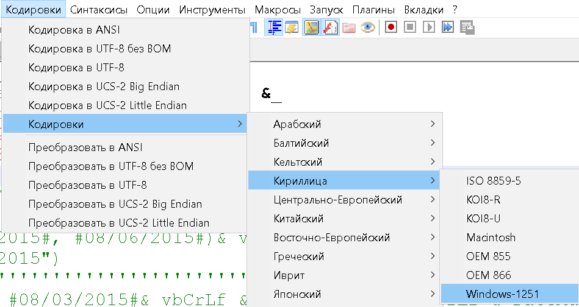

Это избавит от многох проблем  
Горячие клавиши:

- **Ctrl+S** - Сохранить
- **F5** - Запустить, только не забудте указать что

**Notepad++** — это универсальный редактор текстовых файлов, который способен распознавать синтаксисы большого числа языков программирования. Датируется 2003 годом. На нем воросло не одно поколение Web программистов. Де-факто **N++** — это стандарт, за которым пытаются угналься **блокнот**, **WordPad**, **Visual Studio Code** и многие другие легковесные редакторы.  
Visual Studio Code - хоть и навороченный, но слишком нестабильно работает, что удручает.  
**N++** — также позволяет писать и запускать программные коды за через **CMD (F5)**.  
По этому, **N++** может оказаться проще и понятнее чем редактор питона или любого другого языка (главное предварительно файл скрипта "открыть с помощью/$[$Ваш интерпритатор$]$(использовать всегда при запуске файла)").

Теперь о **VBA**

- Rem - комментарий
- ' - комментарий
- " - кавычка
- Dim a 'Создание переменных
- vbCrLf - спец символ перехода на новую строку
- vbTab - спец символ отступа

# MsgBox

$\Uparrow\Uparrow\Uparrow\Uparrow$К оглавлению$\Uparrow\Uparrow\Uparrow\Uparrow$

- MsgBox стандартный вывод сообщений

Dim a, b, c, d  
a = 10  
b = 20  
c = 40  
d = "Привет мир"  
MsgBox a:MsgBox b:MsgBox c:MsgBox d  
'''''''''''''''''''''''''''''''''''''''  
MsgBox d  
MsgBox a  
MsgBox b  
MsgBox c  
MsgBox d

- MsgBox навороченный вывод сообщений
- vbCrLf - спец символ перехода на новую строку
- vbTab - спец символ отступа
- _ - удалить следующий за символом переход на новую строку

MsgBox "Привет мир"  
MsgBox _  
"Привет мир" & vbCrLf &_  
"Символом <_> переношу инструкции на другую строку"& vbCrLf & _  
" ""А теперь экранируем кавычки"" "& vbCrLf & _  
"!!!"&vbTab&"!!!"

# Типы данных.

$\Uparrow\Uparrow\Uparrow\Uparrow$К оглавлению$\Uparrow\Uparrow\Uparrow\Uparrow$  
Думаю уже пора  
Empty; Null; Byte; Integer; Long; Currency; Single; Double; String; Date; Boolean; Object; Мы вынуждено процетировали материал с сайта scriptcoding.ru  
Потому что по качеству материала в этом вопросе им уступает даже  
https://docs.microsoft.com/ru-ru/dotnet/visual-basic/language-reference/data-types/ Есть VBA, он синтаксически отличается от VBS. Разница в том что в VBS $As String$ интерпритируется как ошибка.  
В более подробном описании типов данных не уверин что мынуждаемся. Позвольте с этим вопросом отослать к другим источникам.  
Продолжем вот чем. ""C"" - преобразование типов. Есть специальные функции которые позволяют осуществлять приведение к типу: CBool,CByte,CCur,CDate,CDbl,CDec,CInt,CLng,CLngLng,CLngPtr,CSng,CStr,CVar.

# The if

$\Uparrow\Uparrow\Uparrow\Uparrow$К оглавлению$\Uparrow\Uparrow\Uparrow\Uparrow$

- Время ветвлений

Dim a  
a = 10  
if a = 10 then MsgBox "a = 10"

Dim a  
a = 20  
if a = 10 then  
MsgBox "a = 10"  
else  
MsgBox "a != 10"  
end if

Dim a  
a = 10  
'пример третьей конструкции  
if a = 10 then  
MsgBox "a = 10"  
elseif a = 20 then  
MsgBox "a = 20"  
elseif a = 40.5 then  
MsgBox "a = 40,5"  
else  
MsgBox "совпадений не найдено"  
End if

- Select case и этим все сказано

Dim a  
a = 11  
Select case a  
case 3 & b = "b = 3"  
case 10 & b = "b = 10"  
case else  
b = "b = " & a  
End Select  
MsgBox b

# Функции и процедуры

$\Uparrow\Uparrow\Uparrow\Uparrow$К оглавлению$\Uparrow\Uparrow\Uparrow\Uparrow$

- Процедуры - вообще не подразумеваюн возвращаемых значений и использования как лямбда выражений

Sub my_MsgBox(str)  
MsgBox "Как написать процедуру"&vbCrLf&str  
End Sub

- фунуции.

Function fun_name(a, b)  
Dim rezult  
rezult = a+b  
fun_name = rezult  
'присваиваем значение функцие, которое она нам вернёт  
End Function  
MsgBox fun_name(5,110)  
MsgBox fun_name(15,16)  
MsgBox fun_name(25,15)

Sub sub_name(a, b)  
Dim rezult  
rezult = a+b  
MsgBox rezult  
End Sub  
Call sub_name(5,110)  
Call sub_name(15,16)  
Call sub_name(25,15)  
sub_name 25,1

- фунуции и процедуры скриптов *.vbs не подразумевают существования лямбда выражений. В более поздней версии технологий есть заплатки для лямбда-выражений для макросов VBA-Excel и VBA-VisualStudio-2019
- Функции как переменные. Передача через указатель.  
  Указатель - это адрес виртуальной памяти программы.  
  Есть реальная машинная оперативная память. Она дробится на страници, который предоставляются Вашей программе.  
  По этому оперативная память прорграммы - виртуальная - и состоит из произвольных страниц реальной памяти.  
  По этому, скорее всего, (виртуальная) память программы обладает своей внутренней адресацией. Указатель на область памяти это бинарный тип данных, битность или размерность которого зависит от типа операционной системы.  
  16 битный Dos и ранние версии Windows обладали указателем **Word** (16 битное машинное бинарное слово).  
  32 битный Windows обладали указателем **DWord** (32 битное машинное бинарное слово).  
  64 битный Windows скорее всего обладали указателем **qword** (64 битное машинное бинарное слово).  
  Но почему - то на практике используется **DWord**  
  На будующее, существуют 128 битный **dqword**, скорее всего он используется для **MMX** быстрое сложений массивов в сопроцессорах и видеокартах, отношение к указателям он не имеет...  
  48 бит - **fword**, **pword** - предположительно операции с плавающей запятой...  
  Существует примерно 519 битный **AVX** - быстрое сложение сверх длинных массивов в целях мультимедии.  
  И так, это было лирическое отступление в сторону машинно ориентированного программирования на FASM.
- **Нам просто нужно знать что есть указатель**, он из нулей и единиц, он очень длинный и по этому его представляют в 16-ричном формате. Даже так содержимое указателя для человека трудно интерпретируемо и несет слишком мало смыслового содержания (для обычного программиста). Указатель указывает на область памяти в которой хранитьтся значение переменной или исполняемый программный код функции... Указатель может быть висячим, то есть ссылается на недопустимую область памяти и её использование приведет к закрытию программы. Указатель может обнулен, что предотвращает его последующее использование.

Dim Pointer  
Function fun_name(a,b)  
fun_name = a+b  
MsgBox "a+b=" & a & "+" & b & "=" & fun_name  
End Function  
Set Pointer = getref("fun_name")  
MsgBox Pointer(10,5)

Dim Pointer  
Sub fun_name(a,b)  
MsgBox "a+b=" & a & "+" & b & "=" & a+b  
End Sub  
Set Pointer = getref("fun_name")  
MsgBox Pointer(10,5)

# Циклы

$\Uparrow\Uparrow\Uparrow\Uparrow$К оглавлению$\Uparrow\Uparrow\Uparrow\Uparrow$

- Циклы 1

i = 0  
Do While (i $<$ 3)  
List = list & i & vbCrlf  
i = i + 1  
loop  
MsgBox List

- Циклы 2

i = 0  
Do  
List = list & i & vbCrlf  
i = i + 1  
loop While (i $<$ 3)  
MsgBox List

- Циклы 3

i = 0  
While i$<$3  
List = list & i & vbCrlf  
i = i + 1  
Wend  
MsgBox List

- Циклы 4

i=0  
While Not i = 10  
List2 = List2 & i & vbCrlf  
i = i + 1  
Wend  
MsgBox List2

- Циклы 5

i = 0  
Do  
MsgBox "Пример №4: " & i  
i = i + 1  
loop Until (i>3)

- Циклы 6

i = 0  
Do Until (i$>$3)  
MsgBox "Пример №3: " & i  
i = i + 1  
If i = 2 Then Exit Do  
loop

- Циклы 7

dim arr(5)  
arr(0) = "ПонедельниК"  
arr(1) = "Вторник"  
arr(2) = "Среда"  
arr(3) = "Четверг"  
arr(4) = "Пятница"  
arr(5) = "Суббота"  
for each index in arr  
List = List & index & vbCrLf  
next  
MsgBox List

# Массивы

$\Uparrow\Uparrow\Uparrow\Uparrow$К оглавлению$\Uparrow\Uparrow\Uparrow\Uparrow$

- Массивы 1

dim arr(2)  
arr(0) = 100  
arr(1) = "строка"  
arr(2) = #12/05/2015#  
MsgBox _  
arr(0) & VbCrLf &_  
arr(1) & VbCrLf &_  
arr(2) & VbCrLf &_  
"!!!"

- Массивы 2

dim arr(2,3)  
arr(0,0) = "00"  
arr(0,1) = "01"  
arr(0,2) = "02"  
arr(0,3) = "03"  
arr(1,0) = "10"  
arr(1,1) = "11"  
arr(1,2) = "12"  
arr(1,3) = "13"  
arr(2,0) = "20"  
arr(2,1) = "21"  
arr(2,2) = "22"  
arr(2,3) = "23"  
MsgBox _  
arr(0,0) & vbTab & arr(0,1) & vbTab & arr(0,2) & vbTab &arr(0,3) & VbCrLf &_  
arr(1,0) & vbTab & arr(1,1) & vbTab & arr(1,2) & vbTab &arr(1,3) & VbCrLf &_  
arr(2,0) & vbTab & arr(2,1) & vbTab & arr(2,2) & vbTab &arr(2,3) & VbCrLf &_  
"!!!"

- Массивы 3

List="динамический массив" & vbCrlf  
dim dyn_name()  
i = 0  
Do  
'перезаписываем размерность массива  
'с сохранением имеющийся информации  
Redim Preserve dyn_name(i)  
'присваиваем значение каждому элементу массива  
dyn_name(i) = i  
List=List & i &"="& dyn_name(i) & vbCrlf  
i = i + 1  
loop Until (i$>$20)  
MsgBox List

- Массивы 4
- LBound(arr) - нахождение минимального индекса массива
- UBound(arr) - нахождение максимального индекса массива

dim arr(4)  
arr(0) = "$<-0->$"  
arr(1) = "$<-1->$"  
arr(2) = "$<-2->$"  
arr(3) = "$<-3->$"  
arr(4) = "$<-4->$"  
MsgBox _  
"arr={"&_  
arr(0) &";"&_  
arr(1) &";"&_  
arr(2) &";"&_  
arr(3) &";"&_  
arr(4) &";"&_  
"};"& VbCrLf &_  
"LBound(arr)="&LBound(arr)& VbCrLf &_  
"UBound(arr)="&UBound(arr)& VbCrLf &_  
"arr(LBound(arr))="&arr(LBound(arr))& VbCrLf &_  
"arr(UBound(arr))="&arr(UBound(arr))& VbCrLf &_  
"!!!"

- Массивы 5  
  Массив внутри массива...

dim arr_name  
arr_name = Array(Array(10,"строка",#12/05/2015#,54),Array(11,3,15,44),Array(18,37,16,34)) 'задаём значения для элементов массива  
MsgBox arr_name(0)(2) & vbCrlf & arr_name(1)(2) & vbCrlf & arr_name(2)(2)

- Массивы $/$ Фильтры 1

arr = Array("ПонедельниК","Вторник","Среда","Четверг","Пятница","Суббота")  
Arr_Filter = Filter(arr, "ик", false, 1)  
Arr_Filter = Filter(arr, "ик", false, 1)  
for each index in Arr_Filter  
List = List & index & vbCrLf  
next  
MsgBox List

a=Array("Sunday","Monday","Tuesday","Wednesday","Thursday","Friday","Saturday")  
b=Filter(a,"S",True,1)  
for each index in b  
List = List & index & vbCrLf  
next  
MsgBox List

# Join и Split, Массивы

$\Uparrow\Uparrow\Uparrow\Uparrow$К оглавлению$\Uparrow\Uparrow\Uparrow\Uparrow$

- Join - объединяет массив, в текст, добовляя разделительный символ

arr = Array("ПонедельниК","Вторник","Среда","Четверг","Пятница","Суббота")  
Arr_Join = Join(arr, ",")  
MsgBox Arr_Join

- Split - разделяет текст по разделительному символу, превращая его в массив

arr=Split("ПонедельниК,Вторник,Среда,Четверг,Пятница,Суббота",",")  
for each index in arr  
List = List & index & vbCrLf  
next  
MsgBox List

# DateNow

$\Uparrow\Uparrow\Uparrow\Uparrow$К оглавлению$\Uparrow\Uparrow\Uparrow\Uparrow$

MsgBox _  
"Date = " & Date & vbCrLf &_  
"Now = " & Now & vbCrLf &_  
#12/05/2010# & vbCrLf &_  
#15.05.10# & vbCrLf &_  
"!!!"

rem DatePart("yyyy",Now)  
rem yyyy - Year  
rem q - Quarter  
rem m - Month  
rem y - Day of year  
rem d - Day  
rem w - Weekday  
rem ww - Week of year  
rem h - Hour  
rem n - Minute  
rem s - Second

MsgBox _  
"Разница даты времени"& vbCrLf &_  
"Прошло 72 часа = " & DateDiff("h", #08/03/2015#, #08/06/2015#)& vbCrLf &_  
"Прошло 3 дня = " & DateDiff("d", "03/08/2015", "06/08/2015")& vbCrLf &_  
"!!!"

MsgBox _  
#08/03/2015#& vbCrLf &_  
"+8 месяцев"& vbCrLf &_  
DateAdd("m", 8, #08/03/2015#) & vbCrLf &_  
"-8 месяцев"& vbCrLf &_  
DateAdd("m", -8, #08/03/2015#)& vbCrLf &_  
"!!!"

MsgBox Now  
MsgBox _  
Now & vbCrLf &_  
"m =" & DatePart("m", #08/03/2015#) & vbCrLf &_  
"d =" & DatePart("d", #08/03/2015#) & vbCrLf &_  
"q =" & DatePart("q", #08/03/2015#) & vbCrLf &_  
"!!!"

MsgBox _  
"Часы: " & Hour(Now) & vbCrLf &_  
"Минуты: " & Minute(Now) & vbCrLf &_  
"Месяц: " & Month(Now) & vbCrLf &_  
"День: " & Day(Now) & vbCrLf &_  
"Год: " & Year(Now) & vbCrLf &_  
"Время: " & TimeValue(Now) & vbCrLf &_  
"!!!"

MsgBox _  
DateValue(now) & vbCrLf &_  
DateValue("14, февраль, 1995") & vbCrLf &_  
DateValue("02,14,1995") & vbCrLf &_  
DateValue("02/14/1995") & vbCrLf &_  
"!!!"

MsgBox _  
"Now = " & Now & vbCrLf &_  
"FormatDateTime(Now, 0) = " & FormatDateTime(Now, 0) & vbCrLf &_  
"FormatDateTime(Now, 1) = " & FormatDateTime(Now, 1) & vbCrLf &_  
"FormatDateTime(Now, 2) = " & FormatDateTime(Now, 2) & vbCrLf &_  
"FormatDateTime(Now, 3) = " & FormatDateTime(Now, 3) & vbCrLf &_  
"FormatDateTime(Now, 4) = " & FormatDateTime(Now, 4) & vbCrLf &_  
"!!!"

# Timer

$\Uparrow\Uparrow\Uparrow\Uparrow$К оглавлению$\Uparrow\Uparrow\Uparrow\Uparrow$

Dim old_time, my_timer, i  
old_time = Timer  
i = 0  
While i$<$10000000  
i = i + 1  
Wend  
my_timer = Timer - old_time  
MsgBox "Цикл был выполнен за " & my_timer & " секунд."

# TimeSerial и DateSerial

$\Uparrow\Uparrow\Uparrow\Uparrow$К оглавлению$\Uparrow\Uparrow\Uparrow\Uparrow$

- TimeSerial и DateSerial - позволяет указать час, минуту, секунду, если указали слишком большое значение, то тогда остаток просто перекидывается на старший разряд. Так можно из времени получить дату.

MsgBox _  
"TimeSerial(10,25,25)=" & TimeSerial(10,25,25) & vbCrLf & _  
"TimeSerial(66,55,85)=" & TimeSerial(66,55,85) & vbCrLf & _  
"DateSerial(2016,12,23)=" & DateSerial(2016,12,23) & vbCrLf & _  
"!!!"

- Есть много весьма изетерических по сегодняшним меркам команд, вот некоторые из них:

MsgBox WeekDay(#14/02/1995#, vbSunday)

- указываеш дату и день с которого начинается неделя и возвращает номер дня в неделе.

- Далее без комментариев. Попробуйте сами.

MsgBox WeekDay(#14/02/1995#, vbSunday)  
MsgBox WeekdayName(3, False, vbMonday) & vbCrLf & WeekdayName(3, True, vbMonday)  
MsgBox MonthName(9,true) & vbCrLf & MonthName(9,false)

If IsDate("10/14/2012") then  
MsgBox "Дата корректна!"  
else  
MsgBox "Дата не корректна!"  
end if

- На этом следует закончить, есть ещё более интерестные приключения...
- Если чего в этих примерах нет, то тогда можно поискать в интернете.)

# Математика

$\Uparrow\Uparrow\Uparrow\Uparrow$К оглавлению$\Uparrow\Uparrow\Uparrow\Uparrow$  
rem Abs — Позволяет получить абсолютное число. Проще говоря — модуль.  
rem Atn — Вернёт арктангенс числа.  
rem Cos — возвращает косинус угла, указанный в радианах. Вернёт промежуток от -1 до 1.  
rem Sin — вернёт синус угла, который мы указали в радианах. Вернёт промежуток от -1 до 1.  
rem Tan — возвращает тангенс угла. Значение угла указывать в радианах.  
rem Exp — возвращает нам экспоненту, возведённую в указанное число.  
rem Log — получаем натуральный логарифм из указанного числа. Число должно быть больше 0.  
rem Sqr — вернёт квадратный корень указанного числа.

MsgBox _  
"Модуль числа 10: " & Abs(10) & vbCrLf & _  
"Арктангенс числа 10: " & Atn(10) & vbCrLf & _  
"Косинус угла 10 радиан: " & Cos(10) & vbCrLf & _  
"Синус угла 10 радиан: " & Sin(10) & vbCrLf & _  
"Тангенс угла 10 радиан: " & Tan(10) & vbCrLf & _  
"Экспонента возведённая в 2: " & exp(2) & vbCrLf & _  
"Логарифм из 15: " & log(15) & vbCrLf & _  
"Десятичный логарифм из 15: " & log(15)/log(10) & vbCrLf & _  
"Квадратный корень 15: " & Sqr(15) & vbCrLf & _  
"Квадратный корень 0: " & Sqr(0) & vbCrLf & _  
"!!!"

Randomize  
MsgBox _  
"Генератор чисел в интервале от 0 до 1" & vbCrLf & _  
Rnd & vbCrLf & Rnd & vbCrLf & Rnd & vbCrLf & _  
Rnd & vbCrLf & Rnd & vbCrLf & Rnd & vbCrLf & _  
Rnd & vbCrLf & Rnd & vbCrLf & Rnd & vbCrLf & _  
Rnd & vbCrLf & Rnd & vbCrLf & Rnd & vbCrLf & _  
Rnd & vbCrLf & Rnd & vbCrLf & Rnd & vbCrLf & _  
"!!!"

MsgBox _  
"Округления:"& vbCrLf &_  
"Int(10.3) = "& Int(10.3) & vbCrLf &_  
"Fix(10.3) = "& Fix(10.3) & vbCrLf &_  
"Int(-10.3) = "& Int(-10.3) & vbCrLf &_  
"Fix(-10.3) = "& Fix(-10.3) & vbCrLf &_  
"!!!"

rem FormatNumber  
rem Expression — Единственный обязательный параметр. Само число.  
rem Numdigits — количество знаков после десятичной точки (запятой). Если -1, то по параметрам системы.  
rem Leadingdigit — определяет, будет ли отображаться ноль слева от запятой, в дробных выражениях меньше единицы (00,1)  
rem Useparens — нужно ли заключать отрицательные значения в круглые скобки.  
rem Groupdigits — нужна ли группировка цифр в числе.

MsgBox _  
"FormatNumber(-00.13,3,-1,-1,vbTrue) = "&FormatNumber(-00.13,3,-1,-1,vbTrue) & vbCrLf &_  
"FormatNumber(-00.13,3,-1,0,0) = "&FormatNumber(-00.13,3,-1,0,0)& vbCrLf &_  
"FormatNumber(-00.13) = "&FormatNumber(-00.13)& vbCrLf &_  
"!!!"

rem FormatCurrency — форматирует число как денежную строку с добавление денежного знака.  
rem FormatPercent — возвращает отформатированное число как проценты. Умножает на 100 и добавляет знак %.

MsgBox _  
"FormatCurrency(1000,3,-1,-1) = " & FormatCurrency(1000,3,-1,-1)& vbCrLf &_  
"FormatPercent(100,0,-1,-1) = " & FormatPercent(100,0,-1,-1)& vbCrLf &_  
"!!!"

MsgBox _  
"Hex(1000) = " & "16x" & Hex(1000)& vbCrLf &_  
"Oct(1000) = " & "8x"& Oct(1000)& vbCrLf &_  
"!!!"

MsgBox _  
"Проверка на число" & vbCrLf &_  
"IsNumeric(""67325"") = " & IsNumeric("67325")& vbCrLf &_  
"IsNumeric(""673ae25"") = " & IsNumeric("673ae25")& vbCrLf &_  
"IsNumeric(""fd,glkdfhgjk"") = " & IsNumeric("fd,glkdfhgjk")& vbCrLf &_  
"!!!"

# Строки

$\Uparrow\Uparrow\Uparrow\Uparrow$К оглавлению$\Uparrow\Uparrow\Uparrow\Uparrow$  
Лирическое отступление.  
Просто вселенской проблемой (в с++ и в ассемблере) является проверка отдельного взятогог бита в регистре. Для этого изобретаются велосипеды и магические команды. В многие микропроцессоры добавляются специальные расширения для решения этого вопроса. Этот путь является в корне не верным, так как плодит Левую и быстро устаревающую информацию. На наше счастье есть совершенно стандартный и для школьного курса весьма олимпиадный вариант решения этой задачи - это битовая маска. Применяется побитовая операция между тестируемым значением и битовой маской. На выходе получаем значение отличное от нуля если маска совпала с тестируемым числом. Битовой маской называется машинное стово из нулей, у которого стоит единица на месте тестируемого разряда.  
Сдесь решается похожая задача. Только вместо битов вуступают символы.  
По мне эти функции сильно лишние, но это V B A, и на нем писали мастера и сверх люди прошлых веков!!!  
Здесь приведены несколько очень похожих примеров, разберите их медленно и вдумчиво.  
При беглом чтении они вдрызг похожи, но это не так.

MsgBox _  
"Ищем символ с начала строки с символа номер 1" & vbCrlf & _  
"123456" & vbCrlf & _  
"abcdef" & vbCrlf & _  
"abc^" & vbCrlf & _  
"InStr(1,""abcdef"",""d"")=" & InStr(1,"abcdef","d") & vbCrlf & _  
"!!!"

MsgBox _  
"Ищем символ с начала строки с символа номер 5 - смотрите, не найдем" & vbCrlf & _  
"123456" & vbCrlf & _  
"abcdef" & vbCrlf & _  
"abc^" & vbCrlf & _  
"InStr(5,""abcdef"",""d"")=" & InStr(5,"abcdef","d") & vbCrlf & _  
"!!!"

MsgBox _  
"Ищем символ с конца строки с символа номер 5 - смотрите,найдем" & vbCrlf & _  
"123456" & vbCrlf & _  
"abcdef" & vbCrlf & _  
"abc^" & vbCrlf & _  
"InStrRev(""abcdef"",""d"",5)=" & InStrRev("abcdef","d",5) & vbCrlf & _  
"!!!"

MsgBox _  
"Ищем символ ...- смотрите,не найдем" & vbCrlf & _  
"123456" & vbCrlf & _  
"abcdef" & vbCrlf & _  
"abc^" & vbCrlf & _  
"InStrRev(""abcdef"",""D"",3)=" & InStrRev("abcdef","D",6,0) & vbCrlf & _  
"!!!"

Ближе к делу...

Строки делятся на изменяемые и не изменяемые. Неизменяемые строки вшиты во все языки программировнаия по причине своей первозданности, пришедшей из ассемблера. Изменение неизменяемой строки, обычно, это создание новой строки, с поочередным посимвольным копированием из старой строки с учетом внесенных изменений. Изменяемые строки - попытка программистов избавитьт сервера от перебирания длинных строк по сто раз (это очень медленно). Минус изменяемых строк в том что чаще всего все процедуры для них писать самому. Для изменяемых строк процедуры уже обычно написаны.  
Что на эту тему сказал Ассемблер: "П-ф-ф, хватит лениться!!! Используй тектовый и мультимедийный (FPU/GPU) сопроцессор!!!"  
Что на эту тему сказал С++: "АРИФМЕТИКА УКАЗАТЕЛЕЙ ВСЕ СТЕРПИТ!!! Пишите процедуры сами".  
Что на эту тему сказал #С: "Ничего не знаю, вот мои стандартные библиотечные процедуры.".  
Что на эту тему сказал Pyton: "Строки, какие строки?".  
Что на эту тему сказал JavaScript: "2 гига оперативной памяти и браузер все стерпят!!!".  
Вот весь базар что творится на эту тему.  
Итог: програмеры читают "Крутые книжульки" и безопеляционно цитируют на лево и на право, не взирая на ситуацию. Пусть даже и выглядит это крайне глупо. Они ведь родились раньше нас, значит они правее!!!)  
Некоторые стараются таким образом защишать свой узкий кругозор от износилования новой литературой...  
Тем неменее посмотреть что творилось в VBA мы обязаны...

Msgbox _  
"Вырезание части строки" & vbCrlf & _  
"123456" & vbCrlf & _  
"abcdef" & vbCrlf & _  
Mid("abcdef",InStr(3,"abcdef","c",1)) & vbCrlf &_  
"!!!"

Msgbox _  
"Приводим К Верхнему регистру" & vbCrlf & _  
LCase("Приводим К Нижнему регистру") & vbCrlf & _  
UCase("Приводим К Верхнему регистру") & vbCrlf & _  
"!!!"

Msgbox _  
"abcdef" & vbCrlf & _  
"Выдрать символы с лева:" & Left("abcdef",3) & vbCrlf & _  
"Выдрать символы с права:" & Right("abcdef",3) & vbCrlf & _  
"!!!"

Msgbox _  
"Удаляем пробелы " & vbCrlf & _  
"$<$ a b c d e f $>$" & vbCrlf & _  
"LTrim("" a b c d e f "") $=<$" & LTrim(" a b c d e f ") &"$>$"& vbCrlf & _  
"Trim("" a b c d e f "") $=<$" & Trim(" a b c d e f ") &"$>$"& vbCrlf & _  
"RTrim("" a b c d e f "") $=<$" & RTrim(" a b c d e f ") &"$>$"& vbCrlf & _  
"!!!"

Msgbox _  
"Заменяем кусок в тексте" & vbCrlf & _  
"VBHack.Ru лучший сайт!" & vbCrlf & _  
Replace("VBHack.Ru лучший сайт!","лучший","самый лучший") & vbCrlf & _  
"!!!"

Msgbox _  
"Хочу 10 пробелов:$<$"&Space(10)&"$>$" & vbCrlf & _  
"Хочу 10 десять восклицательных знаков:$<$"&String(10,"!")&"$>$" & vbCrlf & _  
"!!!"

Msgbox _  
"Сравниваем строки" & vbCrlf & _  
"Принцип работы - классический компанатор в котором 0 означает равно" & vbCrlf & _  
"StrComp(""12346"",""12345"")=" &StrComp("12346","12345")& vbCrlf & _  
"StrComp(""12345"",""1234"")=" &StrComp("12345","1234")& vbCrlf & _  
"StrComp(""12345"",""12345"")=" &StrComp("12345","12345")& vbCrlf & _  
"StrComp(""1234"",""12345"")=" &StrComp("1234","12345")& vbCrlf & _  
"StrComp(""12345"",""12346"")=" &StrComp("12345","12346")& vbCrlf & _  
"!!!"

Msgbox _  
"Перестановка символов" & vbCrlf & _  
"унитаз" & vbCrlf & _  
StrReverse("унитаз") & vbCrlf & _  
"Len(""унитаз"")=" &Len("унитаз") & vbCrlf & _  
"Asc(""A"")=" & Asc("A") & vbCrlf & _  
"Chr(65)=" & Chr(65) & vbCrlf & _  
"!!!"

# Консоль VBS, на нашу голову!

$\Uparrow\Uparrow\Uparrow\Uparrow$К оглавлению$\Uparrow\Uparrow\Uparrow\Uparrow$  
Предисловие.  
Как вы пониамете, ничто не берется на пустом месте. Всегда что-то есть до нас. Все материалы появившиеся сдесь претерпели доработку, по сравнению с первоисточниками. Автор не всегда может обозреть всю предметную область, по этому навярника что либо упускает из виду.  
Теперь ругнусь. Писать нужно с наименьшим уровнем иерархии, чтобы быть понятым по первоисточникам с первого раза. Вот Вам переработанный пример работы с консолью. Предыдущий автор наворотил кучу всего своего. Мы же постарались оставить только суть. Судите сами

'Создание консоли  
Set WShell = CreateObject("WScript.Shell")  
vbsInterpreter = "cscript.exe"  
'Фокус на консоль  
If InStr(LCase(WScript.FullName), vbsInterpreter) = 0 Then  
WShell.Run vbsInterpreter & " //NoLogo " & Chr(34) & WScript.ScriptFullName & Chr(34)  
WScript.Quit  
End If  
WScript.StdOut.WriteLine "##########################"

'Использование консоли  
'Вывод в консоль текста с переходом на новую строку  
WScript.StdOut.WriteLine "Привет МиР!!!"  
'Вывод в консоль текста без перехода на новую строку  
WScript.StdOut.Write "Именуйте себя, мастер Сама:"  
'Ввод текста с клавиатуры  
MyVar = LCase(WScript.StdIn.ReadLine)  
'Ожидание чуда, целая секунда  
WScript.Sleep Int(1000)  
WScript.StdOut.WriteLine "Самопровозглашенный Мастер Сама " & MyVar  
WScript.Sleep Int(5000)  
'Консоль закрывается сама

Как видете даже в проработанном примере проблемы с кодировкой чтеня и вывода русского текста.

# Файлы майн системен)

$\Uparrow\Uparrow\Uparrow\Uparrow$К оглавлению$\Uparrow\Uparrow\Uparrow\Uparrow$  
[Пока стоит Microsoft, живее всех живых и V B A. Это ссылка на официальный сайт, по кторому проще всего доизучить эту тему.](https://docs.microsoft.com/ru-ru/office/vba/language/reference/user-interface-help/filesystemobject-object)

Теперь о зайчиках. Самое главное изучать вопросы связыные с файловой системой через консоль. Иначе будет треш.  
Первый вопрос который принято задавать после (каждый додумывает сам) это: "Где я?"

Set oWSH = CreateObject("WScript.Shell")  
vbsInterpreter = "cscript.exe"  
If InStr(LCase(WScript.FullName), vbsInterpreter) = 0 Then  
oWSH.Run vbsInterpreter & " //NoLogo " & Chr(34) & WScript.ScriptFullName & Chr(34)  
WScript.Quit  
End If  
WScript.StdOut.WriteLine "##########################"

WScript.StdOut.WriteLine "Кто Я?"  
WScript.StdOut.WriteLine "Ответ: " & WScript.ScriptFullName  
WScript.StdOut.WriteLine "Где Я?"  
WScript.StdOut.WriteLine "Ответ: " & _  
( _  
CreateObject("Scripting.FileSystemObject") _  
.GetParentFolderName(WScript.ScriptFullName) _  
)  
WScript.StdOut.WriteLine "Кто меня разбудил (запустил)?"  
WScript.StdOut.WriteLine "Ответ: " & WShell.CurrentDirectory  
WScript.StdOut.WriteLine "##########################"

WScript.StdOut.WriteLine "Хочу видеть остальные файлы в этой папке: "  
for each index in _  
CreateObject("Scripting.FileSystemObject") _  
.GetFolder(_  
CreateObject("Scripting.FileSystemObject") _  
.GetParentFolderName(WScript.ScriptFullName) _  
).Files  
WScript.StdOut.WriteLine CStr(index)  
next  
WScript.StdOut.WriteLine "##########################"

WScript.StdOut.WriteLine "Хочу видеть остальные папки в этой папке: "  
for each index in _  
CreateObject("Scripting.FileSystemObject") _  
.GetFolder(_  
CreateObject("Scripting.FileSystemObject") _  
.GetParentFolderName(WScript.ScriptFullName) _  
).SubFolders  
WScript.StdOut.WriteLine CStr(index)  
next  
WScript.StdOut.WriteLine "##########################"

До крайности хайпово было бы создать свой собственный файловый менеджен на основе $*$.vbs и пусть все кто могут читают такой бестселлер).  
Итак с вопросами массового обозрения разобрались, осталось углубиться в частности.

rem Есть один незримый вселенский косяк.  
rem Точка старта программы НЕ совпадает с её папкой по умолчанию  
rem Если Вы запускатете из N++  
rem Косяк досадный но исправимый  
WShell.CurrentDirectory = CreateObject("Scripting.FileSystemObject") _  
.GetParentFolderName(WScript.ScriptFullName)  
rem Теперь создадим папку имени величайшего бойца вселенной котиков)  
If CreateObject("Scripting.FileSystemObject").FolderExists("KoteCombo") then  
WScript.StdOut.WriteLine ("KoteCombo Создан до нас")  
else  
WScript.StdOut.WriteLine ("KoteCombo Будет сотворен")  
set new_folder = CreateObject("Scripting.FileSystemObject").CreateFolder("KoteCombo")  
End If  
WScript.Sleep Int(4000)

WShell.CurrentDirectory = CreateObject("Scripting.FileSystemObject") _  
.GetParentFolderName(WScript.ScriptFullName)  
If CreateObject("Scripting.FileSystemObject").FileExists("KoteCombo.bat") then  
WScript.StdOut.WriteLine ("KoteCombo.bat Создан до нас")  
else  
WScript.StdOut.WriteLine ("KoteCombo.bat Будет сотворен")  
Set new_file = CreateObject("Scripting.FileSystemObject")_  
.CreateTextFile("KoteCombo.bat", True)  
rem полледний булевый парамер отвечает за запись или перезапись  
rem создаем текстовый файл скриптов и пишем в него текст  
new_file.WriteLine("@Echo off")  
new_file.WriteLine("Echo "& Chr(34) & "<>"& Chr(34))  
new_file.WriteLine("pause")  
new_file.Close  
End If  
rem Запускаем получившийся файл в стандартном блокноте  
rem Редактируем, сохраняем. и программа продолжает исполняться дальше  
WShell.Run "notepad"&" KoteCombo.bat", ,true  
WScript.StdOut.WriteLine "##########################"  
WScript.StdOut.WriteLine "Читаем из файла KoteCombo.bat"  
WScript.StdOut.WriteLine "##########################"  
Set f = CreateObject("Scripting.FileSystemObject").OpenTextFile("KoteCombo.bat", 1)  
Do While Not f.AtEndOfStream  
WScript.StdOut.WriteLine (f.ReadLine)  
Loop  
f.Close  
WScript.StdOut.WriteLine "##########################"  
rem Запускаем полученный $*$.bat файл в CMD  
WShell.Run "KoteCombo.bat", ,true  
rem Запускаем CMD.exe в интерактивном режиме. Чтобы выйти наберите exit  
WShell.Run "cmd.exe", ,true  
rem Удаляем тот файл что мы создали...  
CreateObject("Scripting.FileSystemObject").DeleteFile("KoteCombo.bat")  
WScript.Sleep Int(4000)

Несмотря на то что пример достаточно типовой, данный пример в таком варианте, удивительно что не встричается.  
Сдесь создается файлик и открывается в блокноте, читается, выводится в консоль, и запускается в командной строке.  
Что очень удобно для применения в виде пользовательского интерфейса и (базового) запуска в консоли.

# Продолжаем изыскания. Нестандартный ввод вывод.

$\Uparrow\Uparrow\Uparrow\Uparrow$К оглавлению$\Uparrow\Uparrow\Uparrow\Uparrow$  
Очень полезной программой бывает генератор имен временных файлов. Используется для того чтобы можно было генерировать временные файлы и не заморачиваться с их не повторяющимися названиями. После использования за собой затереть!!!  
Такие файлы рекомендуется содавать в соответствующих временных подпапках. Да эта задача чуть более сложная, но разобраться по аналогиии можно.

Set WShell = CreateObject("WScript.Shell")  
vbsInterpreter = "cscript.exe"  
'Фокус на консоль  
If InStr(LCase(WScript.FullName), vbsInterpreter) = 0 Then  
WShell.Run vbsInterpreter & " //NoLogo " & Chr(34) & WScript.ScriptFullName & Chr(34)  
WScript.Quit  
End If  
rem ####################################################

Randomize  
dim GetRandomFileName_Check  
dim GetRandomFileName_LastCheck  
Function GetRandomFileName()  
Do  
GetRandomFileName_LastCheck = GetRandomFileName_Check  
GetRandomFileName_Check = _  
CreateObject("wscript.network").UserName &"_"& _  
DatePart("yyyy",Now)&"_"&_  
DatePart("m",Now)&"_"&_  
DatePart("d",Now)&"__"&_  
DatePart("h",Now)&"_"&_  
DatePart("n",Now)&"_"&_  
DatePart("s",Now)&"__"&_  
Int((100 * Rnd) + 1)&_  
".bat"  
loop Until (GetRandomFileName_Check = GetRandomFileName_LastCheck)  
GetRandomFileName = GetRandomFileName_Check  
End Function  
WScript.StdOut.WriteLine "#################################"  
i=0  
While Not i = 20  
WScript.StdOut.WriteLine GetRandomFileName()  
i = i + 1  
Wend  
WScript.Sleep Int(9000)

Остается разобраться с сететевых протоколах, макросах оффиса и HTA

Продолжение следует...  
http://vbhack.ru/uroki-vbscript/urok-vbscript-n5-massivy-i-fnkcii-dlya-raboty-s.html  
https://www.w3schools.com/asp/func_join.asp  
data:text/vbs;base64,z/Do4uXyIOzo8A==  
http://foxtools.ru/Base64  
http://mpbox.ru/collect/html-and-css-tricks/overclock-site/data-url.html  
https://snipp.ru/tools/base64-img

# Написано с помощью

[Anaconda](https://www.anaconda.com/products/individual) & [Jupyter](https://jupyter.org/) & [Julia](https://julialang.org/)

[figure not shown]